# Exercise 3. Logistic regression

*In this exercise we first merged two datasets and created new variables e.g. by calculating averages of weekday and weekend alcohol consumptions.Further we analyzed relationships between alcohol consumption and selected variables by using logistic regression model and odds ratios and explored the predictive power of the model. I studied how alcohol consumption affected to number of school absences and class failures, grades and quality of family relationships.*

**TASKS 1 AND 2**

The data have 370 observations (students) of 51 variables. Information related to the data is presented in the following [link](https://archive.ics.uci.edu/ml/datasets/Student+Performance).

```r
# TASK 1

date()
```

```
## [1] "Thu Nov 12 15:49:06 2020"
```

```r
# read in the data using fread function of data.table package
library(data.table)
alc_consu <- fread("F:/IODS_usb/IODS-project/data/pormath.csv")

# get the names of the variables
names(alc_consu)
```

```
##  [1] "school"     "sex"        "age"        "address"    "famsize"
##  [6] "Pstatus"    "Medu"       "Fedu"       "Mjob"       "Fjob"
## [11] "reason"     "guardian"   "traveltime" "studytime"  "schoolsup"
## [16] "famsup"     "activities" "nursery"    "higher"     "internet"
## [21] "romantic"   "famrel"     "freetime"   "goout"      "Dalc"
## [26] "Walc"       "health"     "n"          "id.p"       "id.m"
## [31] "failures"   "paid"       "absences"   "G1"         "G2"
## [36] "G3"         "failures.p" "paid.p"     "absences.p" "G1.p"
## [41] "G2.p"       "G3.p"       "failures.m" "paid.m"     "absences.m"
## [46] "G1.m"       "G2.m"       "G3.m"       "alc_use"    "high_use"
## [51] "cid"
```

**TASK 3**

I chose variables (i) absence (number of school absences), (ii) failure (no. of past class failures), (iii) G3 (final grade ranging from 0-20) and (iv) famrel (quality of family relationships 1= very bad and 5= excellent).

Alcohol consumption was graded from 1 (1=very low) to 5 (=very high). Division between low and high users (variable high_use) was created by using alcohol consumption of 2 as threshold. Those students whose workday and weekend consumption was higher than 2 were high consumers. So my hypotheses were that higher alcohol consumption lead to higher number of absences and failures, lower grades and these subjects did have lower quality relationship with their family.

**TASK 4**

In total out of 370 students there were 111 high alcohol consumers (41 females and 70 males).

Bit surprisingly high consuming females had better grades (11.8) than low consumers (11.4). High consuming males had clearly lower grades (10.3) than low consuming males (12.3)

Quality of family relationships were bit poorer in high consuming groups (F:3.7 and M:3.8) in comparison to low consuming groups (F:3.9 and M:4.1).

All in all my hypotheses seemed to be correct although females who consumed more alcohol had better grades in comparison to low consuming females.

```r
# TASK 4, numerical summary

# access the tidyverse libraries dplyr and ggplot2
library(dplyr); library(ggplot2)
# produce summary statistics by group
alc_consu %>% group_by(sex, high_use) %>% summarise(count = n(), mean_grade = mean(G3))
```

```
## # A tibble: 4 x 4
## # Groups:   sex [2]
##   sex   high_use count mean_grade
##   <chr> <lgl>    <int>      <dbl>
## 1 F     FALSE      154       11.4
## 2 F     TRUE        41       11.8
## 3 M     FALSE      105       12.3
## 4 M     TRUE        70       10.3
```

```r
alc_consu %>% group_by(sex, high_use) %>% summarise(count = n(), mean_grade = mean(absences))
```

```
## # A tibble: 4 x 4
## # Groups:   sex [2]
##   sex   high_use count mean_grade
##   <chr> <lgl>    <int>      <dbl>
## 1 F     FALSE      154       4.25
## 2 F     TRUE        41       6.85
## 3 M     FALSE      105       2.91
## 4 M     TRUE        70       6.1
```

```r
alc_consu %>% group_by(sex, high_use) %>% summarise(count = n(), mean_grade = mean(failures))
```

```
## # A tibble: 4 x 4
## # Groups:   sex [2]
##   sex   high_use count mean_grade
##   <chr> <lgl>    <int>      <dbl>
## 1 F     FALSE      154      0.104
## 2 F     TRUE        41      0.293
## 3 M     FALSE      105      0.143
## 4 M     TRUE        70      0.386
```

```r
alc_consu %>% group_by(sex, high_use) %>% summarise(count = n(), mean_grade = mean(famrel))
```

```
## # A tibble: 4 x 4
## # Groups:   sex [2]
##   sex   high_use count mean_grade
##   <chr> <lgl>    <int>      <dbl>
## 1 F     FALSE      154       3.92
## 2 F     TRUE        41       3.73
## 3 M     FALSE      105       4.13
## 4 M     TRUE        70       3.79
```

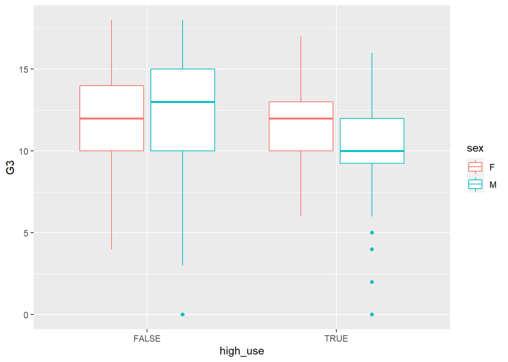

```r
# TASK 4, graphical summary

library(ggplot2)

# initialize a plot of high_use and G3, absences, failures and family relationship
g1 <- ggplot(alc_consu, aes(x = high_use, y = G3, col = sex))
g2 <- ggplot(alc_consu, aes(x = high_use, y = absences, col = sex))
g3 <- ggplot(alc_consu, aes(x = high_use, y = failures, col = sex))
g4 <- ggplot(alc_consu, aes(x = high_use, y = famrel, col = sex))

# define the plot as a boxplot and draw it
g1 + geom_boxplot() + ylab("G3")
```

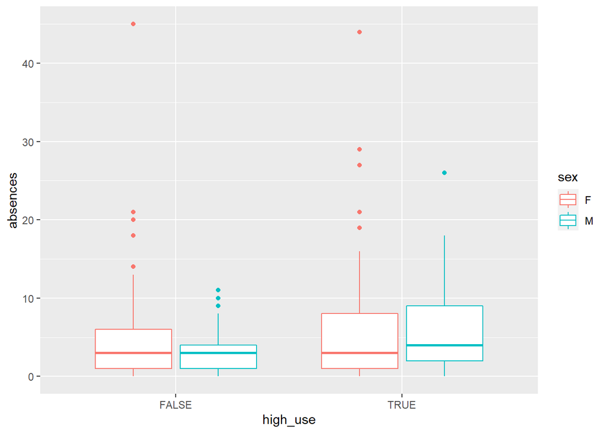

```r
g2 + geom_boxplot() + ylab("absences")
```

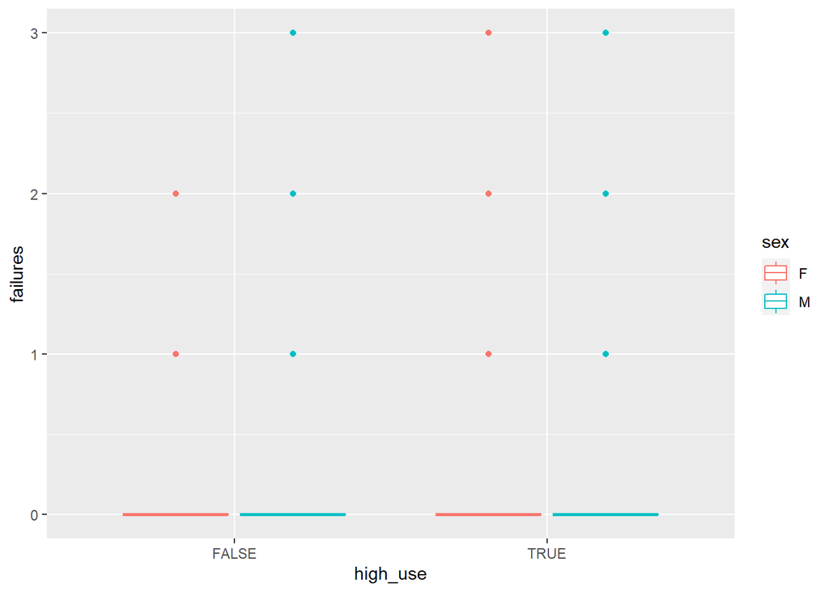

```r
g3 + geom_boxplot() + ylab("failures")
```

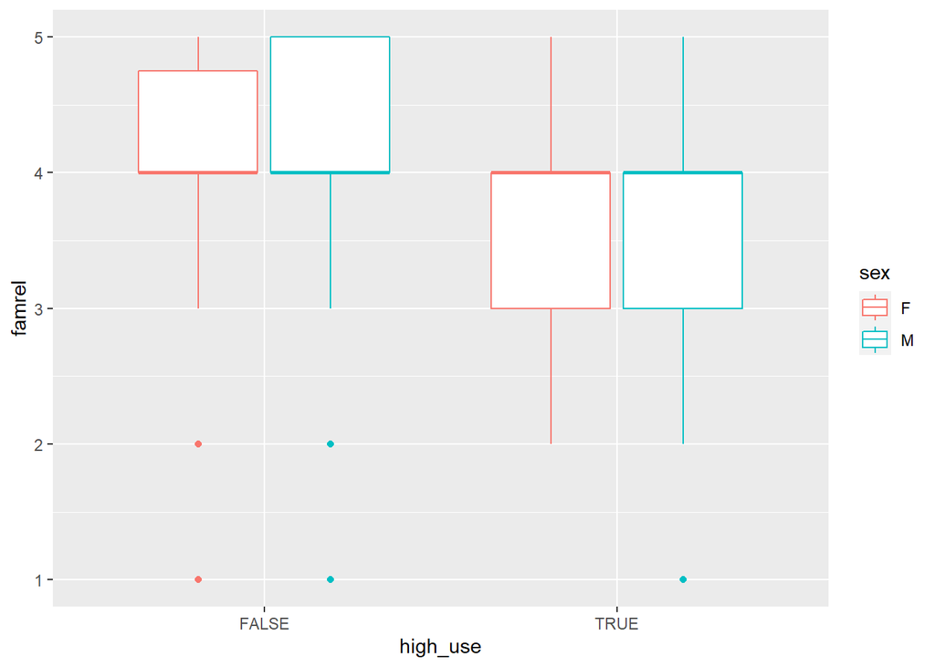

```r
g4 + geom_boxplot() + ylab("famrel")
```

**TASK 5, logistic regression**

Median **deviance residual** (-0.67) was small meaning that the model was not greatly biased.

There was no significant relationship between **grades** and alcohol consumption (p-value 0.31). High alcohol consumption had significant relationship between **failures** (p-value 0.01) and **absences** (p-value < 0.01). **Failures** and **absences** increased when alcohol consumption increased. P-value of quality of family relationship **(famrel)** was only a little over 0.05 so one could say it had also significant relationship to alcohol consumption. Quality of family relations got lower when alcohol consumption was higher.

**Null deviance:** The null deviance tells us how well we can predict our output only using the intercept. Smaller is better.

**Residual deviance:** The residual deviance tells us how well we can predict our output using the intercept and our inputs. Smaller is better

**The Akaike information criteria (AIC)** is used to estimate how well the model describes the patterns in data. It is used to compare models of the same dataset. Lower the score the better.

Explanations for null and residual deviance and the Akaike information criteria (AIC) were found from following [link](https://stats.stackexchange.com/questions/86351/interpretation-of-rs-output-for-binomial-regression).

```r
# TASK 5, logistics regression

# find the model with glm()
glmodel <- glm(high_use ~ G3 + failures + absences + famrel, data = alc_consu, family = "binomial")

# print out a summary of the model
summary(glmodel)
```

```
##
## Call:
## glm(formula = high_use ~ G3 + failures + absences + famrel, family = "binomial",
##     data = alc_consu)
##
## Deviance Residuals:
##     Min       1Q   Median       3Q      Max
## -2.1684  -0.7891  -0.6692   1.1496   1.9954
##
## Coefficients:
##             Estimate Std. Error z value Pr(>|z|)
## (Intercept)  0.06039    0.69094   0.087 0.930348
## G3          -0.03900    0.03860  -1.010 0.312332
## failures     0.54397    0.21204   2.565 0.010306 *
## absences     0.07941    0.02265   3.506 0.000456 ***
## famrel      -0.24827    0.12704  -1.954 0.050682 .
## ---
## Signif. codes:  0 '***' 0.001 '**' 0.01 '*' 0.05 '.' 0.1 ' ' 1
##
## (Dispersion parameter for binomial family taken to be 1)
##
##     Null deviance: 452.04  on 369  degrees of freedom
## Residual deviance: 419.07  on 365  degrees of freedom
## AIC: 429.07
##
## Number of Fisher Scoring iterations: 4
```

```r
# print out the coefficients of the model
coef(glmodel)
```

```
## (Intercept)          G3    failures    absences      famrel
##  0.06039255 -0.03900009  0.54396614  0.07941103 -0.24826624
```

**TASK 5, odds ratios**

Odds Ratio Interpretation [link](https://www.statisticshowto.com/odds-ratio)

- An odds ratio of exactly 1 means that exposure to property A does not affect the odds of property B.
- An odds ratio of more than 1 means that there is a higher odds of property B happening with exposure to property A.
- An odds ratio is less than 1 is associated with lower odds.

```r
# TASK 5, odds ratios

# compute odds ratios (OR)
OR <- coef(glmodel) %>% exp

# compute confidence intervals (CI)
CI <- confint(glmodel) %>% exp
# print out the odds ratios with their confidence intervals
cbind(OR, CI)
```

```
##                    OR     2.5 %   97.5 %
## (Intercept) 1.0622535 0.2716427 4.119475
## G3          0.9617506 0.8914779 1.037582
## failures    1.7228263 1.1429817 2.644153
## absences    1.0826492 1.0378918 1.134607
## famrel      0.7801522 0.6073480 1.001334
```

**TASK 6, predictions**

For this modelling I dropped variable G3 (grades) out of the model as it had no statistically significant relationship with high/low alcohol consumption.

Prediction was set to be true if the value of 'probability' was greater than 0.5.

242 individuals were correctly classified as low alcohol consumers (true negative) while 17 were classified wrongly as high alcohol consumers (false positive). 19 individuals were correctly classified as high alcohol consumers (true positive) while 92 individuals were classified wrongly as low alcohol consumers (false negative).

I tested the model by setting probability of high alcohol use to 0 and 1. With probability 0 average prediction error of the model was 0.3 and with probability of 1 average prediction error was 0.7. The model works better when there are no high alcohol consumers in the dataset.

```r
# TASK 6, predictions

glmodel_1 <- glm(high_use ~ failures + absences + famrel, data = alc_consu, family = "binomial")

# predict() the probability of high_use
probabilities <- predict(glmodel_1, type = "response")

# add the predicted probabilities to 'alc_consu'
alc_consu <- mutate(alc_consu, probability = probabilities)

# use the probabilities to make a prediction of high_use
alc_consu <- mutate(alc_consu, prediction = probability > 0.5)

# see the last ten original classes, predicted probabilities, and class predictions
select(alc_consu, failures, absences, famrel, high_use, probability, prediction) %>% tail(10)
```

```
##     failures absences famrel high_use probability prediction
##  1:        1        7      5     TRUE   0.3870516      FALSE
##  2:        0        3      4     TRUE   0.2393520      FALSE
##  3:        0        2      4     TRUE   0.2249096      FALSE
##  4:        0        4      3     TRUE   0.3047258      FALSE
##  5:        0        3      3    FALSE   0.2878313      FALSE
##  6:        0        4      4     TRUE   0.2544175      FALSE
##  7:        0        0      4    FALSE   0.1979156      FALSE
##  8:        1        4      4     TRUE   0.3887510      FALSE
##  9:        2        8      5     TRUE   0.5606861       TRUE
## 10:        1        0      4    FALSE   0.3150209      FALSE
```

```r
# tabulate the target variable versus the predictions
table(high_use = alc_consu$high_use, prediction = alc_consu$prediction)
```

```
##         prediction
## high_use FALSE TRUE
##    FALSE   242   17
##    TRUE     92   19
```

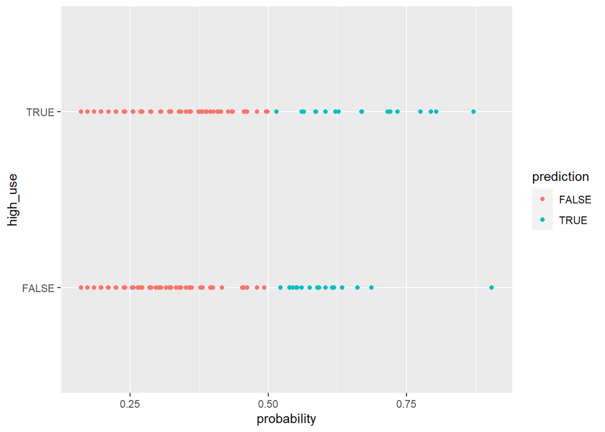

```r
# access dplyr and ggplot2
library(dplyr); library(ggplot2)

# initialize a plot of 'high_use' versus 'probability' in 'alc_consu'
g <- ggplot(alc_consu, aes(x = probability, y = high_use, col = prediction))

# define the geom as points and draw the plot
g + geom_point()
```

```r
# tabulate the target variable versus the predictions
table(high_use = alc_consu$high_use, prediction = alc_consu$prediction) %>% prop.table %>% addmargins
```

```
##         prediction
## high_use      FALSE       TRUE        Sum
##    FALSE 0.65405405 0.04594595 0.70000000
##    TRUE  0.24864865 0.05135135 0.30000000
##    Sum   0.90270270 0.09729730 1.00000000
```

```r
# define a loss function (average prediction error)
loss_func <- function(class, prob) {
  n_wrong <- abs(class - prob) > 0.5
  mean(n_wrong)
}

# call loss_func to compute the average number of wrong predictions in the (training) data
loss_func(class = alc_consu$high_use, prob = alc_consu$probability)
```

```
## [1] 0.2945946
```

```r
loss_func(class = alc_consu$high_use, prob = 0)
```

```
## [1] 0.3
```

```r
loss_func(class = alc_consu$high_use, prob = 1)
```

```
## [1] 0.7
```

**TASK 7, 10-fold cross-validation**

The 10-fold cross-validation of my model (high_use ~ failures + absences + famrel) resulted in prediction error of 0.3, which is little bit higher than datacamp model error 0.26.

```r
# compute the average number of wrong predictions in the (training) data


# K-fold cross-validation
library(boot)
cv <- cv.glm(data = alc_consu, cost = loss_func, glmfit = glmodel_1, K = 10)

# average number of wrong predictions in the cross validation
cv$delta[1]
```

```
## [1] 0.2945946
```